```python
import numpy as np
import pandas as pd
from scipy import stats
import statsmodels.api as sm
from matplotlib import pyplot as plt
import statsmodels.stats.api as sms
from plotly import offline
import plotly.express as px
offline.init_notebook_mode() # offline for better looking interactive graphics
```

# Analyse der Fussball-Weltmeisterschaften

Beschreibende und schliessende Statistik by Mirco Friedli

## Inhaltsverzeichnis

| Kapitel Nr. | Kapitel |
| --- | --- |
| ------------ | ------------------------------------------------------------------------------------------------------- |
| 1.0 | Einleitung |
| 1.1 | Organisation |
| 1.2 | Fragestellung |
| 1.3 | Methoden für die Analyse |
| 2.0 | Beschreibende Statstik |
| 2.1 | Weltmeistertitel mit Histogramm |
| 2.2 | Zuschaueranzahl & Weltmeistertitel im Boxplott |
| 2.3 | Anzahl Tore pro Turnier |
| 2.4 | Anzahl Tore pro Turnier in einem Raster |
| 2.5 | Anzahl Tore pro Turnier in einer Animation |
| 3.0 | Schliessende Statstik |
| 3.1 | Aufbereitung & Visualisierung der Daten |
| 3.1.1 | Einleitung |
| 3.1.2 | Aufbereitung der Daten |
| 3.1.3 | Visualisierung der Daten |
| 3.2 | T-Test Allgemein |
| 3.2.1 | Mittelwert & Standartabweichung |
| 3.2.2 | Welchs t-Test direkt mit Python |
| 3.3 | T-Test Berechnung |
| 3.3.1 | Teststatistik und p-Wert |
| 3.3.2 | Konfidenzinterval durch Signifikanzniveau |
| 3.3.3 | Normalverteilung |
| 3.4 | Mann-Witney Test |
| 4 | Fazit |
| 5 | Quellenverzeichnis |

## 1.0 Einleitung

Die FIFA hat ab 1930 verschiedene Daten der **Fussball-Weltmeisterschaften** zusammengetragen und veröffentlicht. Dieser Datensatz nutze ich nun um eine spannende Story über die Geschichte der Fussball-Weltmeisterschaften zu verfassen.

### 1.1 Organisation

Der Weltfussballverband FIFA organisiert und vermarktet die **Fussball-Weltmeisterschaften** der Männer. Dabei qualifizieren sich Nationalmannschaft periodisch alle vier Jahre für dieses Turnier. Die Weltmeisterschaft wurde immer beliebter und grösser. Dieses Turnier ist gemessen an der Anzahl der weltweiten TV-Zuschauer, die grösste Sportveranstaltung der Welt. Nur die Olympischen Spiele geniessen ebenfalls so viel Beliebtheit in der Weltbevölkerung.

### 1.2 Fragestellung

Durch die Analyse des "WorldCups" Datensatz möchte ich nun folgende Fragestellung beantworten:  
**Wie haben sich Weltmeistertitel, Anzahl Tore, Teilnehmeranzahl und Besucherzahl über die Jahre etwickelt?**

### 1.3 Methoden für die Analyse

In der beschreibenden Statistik visualisiere ich mit verschiedenen Diagramme die oben erwähnte Fragestellung. Des Weiteren umschreibe ich diese erkenntnisse mit einer spannenden Story. Dabei erarbeite ich in der beschreibenden Statistik eine Hypothese, welche ich in der schliessende Statistik belege oder widerlege.

## 2.0 Beschreibende Statistik

Folgende Darstellungsarten werden zur Visualisierung der Daten genutzt.

- Histogramm
- Boxplot
- Scatterplot
- Plot mit facets
- Animation

```python
dataset = pd.read_csv("WorldCups.csv")
dataset.head(20)
```

|  | Year | Country | Winner | Runners-Up | Third | Fourth | GoalsScored | QualifiedTeams | MatchesPlayed | Attendance |
| --- | --- | --- | --- | --- | --- | --- | --- | --- | --- | --- |
| 0 | 1930 | Uruguay | Uruguay | Argentina | USA | Yugoslavia | 70 | 13 | 18 | 590'549 |
| 1 | 1934 | Italy | Italy | Czechoslovakia | Germany | Austria | 70 | 16 | 17 | 363'000 |
| 2 | 1938 | France | Italy | Hungary | Brazil | Sweden | 84 | 15 | 18 | 375'700 |
| 3 | 1950 | Brazil | Uruguay | Brazil | Sweden | Spain | 88 | 13 | 22 | 1'045'246 |
| 4 | 1954 | Switzerland | Germany FR | Hungary | Austria | Uruguay | 140 | 16 | 26 | 76'607 |
| 5 | 1958 | Sweden | Brazil | Sweden | France | Germany FR | 126 | 16 | 35 | 819'810 |
| 6 | 1962 | Chile | Brazil | Czechoslovakia | Chile | Yugoslavia | 89 | 16 | 32 | 893'172 |
| 7 | 1966 | England | England | Germany FR | Portugal | Soviet Union | 89 | 16 | 32 | 1'563'135 |
| 8 | 1970 | Mexico | Brazil | Italy | Germany FR | Uruguay | 95 | 16 | 32 | 1'603'975 |
| 9 | 1974 | Germany | Germany FR | Netherlands | Poland | Brazil | 97 | 16 | 38 | 1'865'753 |
| 10 | 1978 | Argentina | Argentina | Netherlands | Brazil | Italy | 102 | 16 | 38 | 1'545'791 |
| 11 | 1982 | Spain | Italy | Germany FR | Poland | France | 146 | 24 | 52 | 2'109'723 |
| 12 | 1986 | Mexico | Argentina | Germany FR | France | Belgium | 132 | 24 | 52 | 2'394'031 |
| 13 | 1990 | Italy | Germany FR | Argentina | Italy | England | 115 | 24 | 52 | 2'516'215 |
| 14 | 1994 | USA | Brazil | Italy | Sweden | Bulgaria | 141 | 24 | 52 | 3'587'538 |
| 15 | 1998 | France | France | Brazil | Croatia | Netherlands | 171 | 32 | 64 | 2'785'100 |
| 16 | 2002 | Korea/Japan | Brazil | Germany | Turkey | Korea Republic | 161 | 32 | 64 | 2'705'197 |
| 17 | 2006 | Germany | Italy | France | Germany | Portugal | 147 | 32 | 64 | 3'359'439 |
| 18 | 2010 | South Africa | Spain | Netherlands | Germany | Uruguay | 145 | 32 | 64 | 3'178'856 |
| 19 | 2014 | Brazil | Germany | Argentina | Netherlands | Brazil | 171 | 32 | 64 | 3'386'810 |

### 2.1 Weltmeistertitel mit Histogramm

```python
fig = px.bar(dataset, title="Weltmeistertitel", y = "QualifiedTeams", x = "Winner", color = "Year", color_continuous_scale='bluered_r',  text = "Year")
fig.show()
```

[interactive chart not shown]

### 2.2 Zuschaueranzahl & Weltmeistertiel im Boxplott

```python
fig = px.box(dataset, title="Besucheranzahl", x = "Winner", y = "Attendance")
fig.show()
```

[interactive chart not shown]

### 2.3 Anzahl Tore pro Turnier

Kommen wir nun zum Hauptteil, welcher ich Eindrücklich mit einem Scatterplott beginne. Denn durch die Farben sieht man je mehr Spiele gespielt wurden desto mehr Tore wurden erzielt. Ist doch logisch oder? Doch spannend, früher wurden in zwei Spielen pro Spiel mehr Tore erzielt als in jüngster Zeit. Denn wir haben mit 26 Spiele und 140 Tore einen Ausreiser zu beginn der Weltmeisterschaften. Ein zweiter Ausreiser ist erkennbar bei 35 Spielen und 126 Tore. Diese zwei Weltmeisterschaften müssen spannend gewesen sein. Denn wer sieht schon gerne ein Spiel ohne Tore? Zum Schluss kommen die spannenden Resultate mit 52 Spiele. Es gab zwei Spiele in dieser Kategorie, indenen fast gleichviel Tore erzielt wurden wie in den Spielen mit 12 Begegnungen mehr. Somit wurden auch in jüngster Vergangenheit gute Resultate erzielt. Nun zu meiner Hypothese. Wenn man die Scatters so anschaut sieht man bei 38 Spielen einen Schnitt, wobei oberhalb und unterhalb 9 Turniere stattfanden. Nun ist meine Hypothese, dass in den ersten 9 Turniere im Schnitt mehr Tore erzielt wurden als in den letzten 9 Weltmeisterschaften und somit wird das grosse Sportereigniss nicht spannender, nur grösser. Was man hier nicht sieht, wir haben vier Spiele in denen zwei Spiele jeweils die selbe Anzahl an Tore und Spiele hatten. Deshalb zähle ich jeweils 9 Turniere und nicht 8.

```python
fig = px.scatter(dataset, title="Anzahl Tore Teil I", y="Year", x="Winner",
           size="GoalsScored", color="GoalsScored", text="GoalsScored", size_max=30)
fig.update_traces(textposition='top left')
fig.show()
```

[interactive chart not shown]

### 2.4 Anzahl Tore pro Turnier in einem Raster

In diesem sogennanten "Facets" Scatterplott unterteile ich die Anzahl Tore pro Spiele unter den Weltmeistertittel. Somit ist eine Andere Sicht auf das Verhältniss der Tore pro Spiel möglich. Mit diesem Plott möchte ich meine Hypothese nochmals verstärken. Denn je weiter links die Scatter sind in den einzelnen Raster desto älter sind die Weltmeisterschaften. Somit ist mit diesem Beispiel eine andere Perspektive möglich, der erzielten Tore auf die Anzahl Spiele.

```python
fig = px.scatter(dataset, title="Anzahl Tore Teil II", y = "MatchesPlayed", x= "Year",
           size="GoalsScored", range_x=[1920,2025], color="GoalsScored", facet_col = "Winner", facet_col_wrap=3)
fig.for_each_annotation(lambda a: a.update(text=a.text.split("=")[-1]))
fig.show()
```

[interactive chart not shown]

### 2.5 Anzahl Tore pro Turnier in einer Animation

Um die Hypothese und somit die beschreibende Statistik abzurunden, kreierte ich noch ein Scatterplott mit einer Animation. Wenn man die Animation abspielt sieht man schön wie die Bälle (erzielten Tore in einem Turnier) zwei Ausreisenr haben und anschliessend sich von unten Links nach oben Rechts bewegen .

```python
px.scatter(dataset, title="Anzahl Tore Teil III",  x="GoalsScored",y="MatchesPlayed", animation_frame="MatchesPlayed", animation_group="GoalsScored",
           size="GoalsScored", color="GoalsScored", hover_name="GoalsScored",
           size_max=45, range_x=[0,180], range_y=[0,70])
```

[interactive chart not shown]

## 3.0 Schliessende Statistik

Um nun im zweiten Teil meine Hyopthese zu beweisen/widerlegen füre ich einen sogenannten T-Test durch. Dabei erläutere ich jede Schritte genau und versuche die Resultate anschaulich zu Visualisieren.

Nochmal zur Erinnerung vom Teil beschreibende Statistik  
Meine Hyopthese: **In den ersten 9 Turniere (1930 - 1970) wurden im Schnitt mehr Tore erzielt als in den letzten 9 Weltmeisterschaften (1982 - 2014).**

### 3.1 Aufbereitung & Visualisierung der Daten

#### 3.1.1 Einleitung

Um nun die unten stehenden Datan analysieren zu können, müssen diese dementsprechend aufbereitet werden. Im Moment haben wir noch zu viele Informationen in unserem Datensatz. Aus diesem Grund werden nun in einem ersten Schritt die unwichtigen Daten herausgefiltert. In einem zweiten Schritt werden die Anzahl Tore und Anzahl Spiele pro Linie in der Tabelle dividiert. Somit erhalten wir Schlussendtlich ein sogenanntes Wörterbuch bzw. Dictionary indem unsere Mittelwerte Anzahl Tore pro Spiel eingetragen werden.

```python
dataset = pd.read_csv("WorldCups.csv")
dataset.head(3)
```

|  | Year | Country | Winner | Runners-Up | Third | Fourth | GoalsScored | QualifiedTeams | MatchesPlayed | Attendance |
| --- | --- | --- | --- | --- | --- | --- | --- | --- | --- | --- |
| 0 | 1930 | Uruguay | Uruguay | Argentina | USA | Yugoslavia | 70 | 13 | 18 | 590'549 |
| 1 | 1934 | Italy | Italy | Czechoslovakia | Germany | Austria | 70 | 16 | 17 | 363'000 |
| 2 | 1938 | France | Italy | Hungary | Brazil | Sweden | 84 | 15 | 18 | 375'700 |

#### 3.1.2 Aufbereiten der Daten

```python
counter = 0
counter2 = 0
ls1 = []
ls2 = []
ls3 = []
ls4 = []

for row in dataset["GoalsScored"]:
    if counter <= 8:
        ls1.append(row)
    if counter >= 11:
        ls2.append(row)
    counter +=1
for row in dataset["MatchesPlayed"]:
    if counter2 <=8:
        ls3.append(row)
    if counter2 >= 11:
        ls4.append(row)
    counter2 +=1


# Nun den Durchschnitt pro Spiel berechnen, damit wir zwei vergleichbare Variablen haben
ls_var_a = []
ls_var_b = []
index_1 = 0
index_2 = 0
for i in ls1:
    a = i/ls3[index_1]
    ls_var_a.append(round(a))
    index_1 +=1
for i in ls2:
    b = i/ls4[index_2]
    ls_var_b.append(round(b))
    index_2 +=1

dic_goals = {}
dic_goals["Goals: 1930 - 1970"] = ls_var_a
dic_goals["Goals: 1982 - 2014"] = ls_var_b

dic_games = {}
dic_games["Games: 1930 - 1970"] = ls3
dic_games["Games: 1982 - 2014"] = ls4

DF_dic_goals = pd.DataFrame(dic_goals)
DF_dic_games = pd.DataFrame(dic_games)
```

#### 3.1.3 Visualisieren der Daten

Nun können die Daten anschaulich in einem Boxplott Visualisiert werden. Somit ist auf den ersten Blick ersichtlich, dass zwischen 1930 - 1970 mehr Tore im Durschnitt pro Spiel fielen. Zudem sieht man auf dem Boxplott ein Ausreiser mit fünf Tore pro Spiel. Hingegen in den Jahren zwischen 1982 - 2014 ist der Beste Wert gleichschlecht wie der schlechteste Wert in den Jahren 1930 - 1970. Die Annahme welche ich in der beschreibenden Statistik erarbeitet habe scheint somit zu stimmen. Nun werden wir die einzelnen Werte genauer anschauen.

```python
DF_dic_long = pd.melt(DF_dic_goals)

fig = px.box(DF_dic_long, title="Boxplott Goals im Vergleich", x = "variable", y ="value", width = 500, height = 400)

fig.update_layout(yaxis_title="Ø Anzahl Tore pro Spiel")

fig.show()
```

[interactive chart not shown]

```python
DF_dic_long = pd.melt(DF_dic_games)

fig = px.box(DF_dic_long, title="Boxplott Spiele im Vergleich", x = "variable", y ="value", width = 500, height = 400, range_y=[15,70])

fig.update_layout(yaxis_title="Anzahl Spiele pro Turnier",)

fig.show()
```

[interactive chart not shown]

### 3.2 t-Test Allgemein

#### 3.2.1 Mittelwert & Standardabweichungen

Um nun den T-Test durchzuführen, brauchen wir als erstes die Mittelwerte und Standardabweichungen unserer beiden Stichproben. Somit steht die variable x für Mittelwert und s für Standardabweichung. Damit später den Welchs t-Test besser beschrieben werden kann, brauchen wir Hauptsächlich die Mittelwerte und die Standardabweichungen der beiden Stichproben.  
Nun ist hier klar ersichtlich das die Varianzen der beiden Stichproben unterschiedlich sind. Daraus folgt, dass wir den Welchs t-Test anwenden. Der students t-Test ist eher für gleiche Varianzen.

```python
x_1930_1970 = DF_dic_goals["Goals: 1930 - 1970"].mean()
s_1930_1970 = DF_dic_goals["Goals: 1930 - 1970"].std()
print(f"Mittelwert 1930 -1970:\n{round(x_1930_1970, 2)}")
print(f"Standartabweichung 1930 -1970:\n{round(s_1930_1970, 2)}")

x_1982_2014 = DF_dic_goals["Goals: 1982 - 2014"].mean()
s_1982_2014 = DF_dic_goals["Goals: 1982 - 2014"].std()
print(f"Mittelwert 1982 - 2014:\n{round(x_1982_2014, 2)}")
print(f"Standartabweichung 1982 - 2014:\n{round(s_1982_2014, 2)}")

print(f"Varianz Goals: 1930 - 1970 \n{round(s_1930_1970**2, 2)}")
print(f"Varianz Goals: 1982 - 2014 \n{round(s_1982_2014**2, 2)}")
```

```
Mittelwert 1930 -1970:
3.89
Standartabweichung 1930 -1970:
0.78
Mittelwert 1982 - 2014:
2.67
Standartabweichung 1982 - 2014:
0.5
Varianz Goals: 1930 - 1970
0.61
Varianz Goals: 1982 - 2014
0.25
```

#### 3.2.2 Welchs t-Test direkt mit Pyhton

Wie Anfangs beschrieben arbeiten wir nun ausschliesslich mit den Mittelwerten und Standartabweichungen der beiden Stichproben. In Python gibt es für den Welchs t-Test eine funktion teststatstik_welch. Mit diesem t-Test von Python kann man direkt den einseitigen und zweiseitigen Test durchführen. Dies ist allerdings mit vorsicht zu geniessen, denn Python wurde nicht zwingend für die Statistik programmiert und hat somit auch Fehler drin.

```python
teststatistik_welch, pwert_welch = stats.ttest_ind(DF_dic_goals["Goals: 1930 - 1970"],
                                                   DF_dic_goals["Goals: 1982 - 2014"], equal_var = False)
print(f"Teststatstik:\n{teststatistik_welch}")

print(f"Einseitiger Test:\n{pwert_welch/2}")
```

```
Teststatstik:
3.951316644589048
Einseitiger Test:
0.0007623205182193665
```

#### 3.2.3 T-Test direkt mit Pyhton Beobachtung

Ist dieser Wert korrekt. Allerdings muss man hier aufpassen. Denn für den Students t-Test ist diese Formel falsch.

### 3.3 T-Test Berechnung

Um nun die Berechnungen von Python nachvollziehen zu können rechne ich nachfolgend die Teststatistik Schritt für Schritt.

#### p-Wert

[output not shown]

#### Signifikanzniveau & Konfidenzinterval

Das Signifikanzniveau ist $\alpha = 0.05$.

Berechnung des dazugehörigen $1 - \alpha$ Konfidenzinterval für Welchs t-Test.

| **Welchs t-Test** | das zugehörige $95\%$ Konfidenzinterval |
| --- | --- |
| zweiseitig | ca. $\left[0.55 , 1.88 \right]$ |

#### Nullhypothese

Nun kann die Nullhypothese verworfen werden, da der $p$-Wert deutlich kleiner als das gewählte Signifikanzniveau von $\alpha = 0.05$ ist.

#### 3.3.1 Teststatistik und p-Wert

```python
diff_mean = x_1930_1970 - x_1982_2014
s_both = s_1930_1970**2/9 + s_1982_2014**2/9
t = diff_mean/s_both**0.5
print(t)

nenner = (s_1930_1970**2/9 + s_1982_2014**2/9)**2
zaehler = (s_1930_1970**2/9)**2*(1/8) + (s_1982_2014**2/9)**2*(1/8)
df_welch = nenner/zaehler
print((1-stats.t.cdf(t, df = df_welch))) # zweiseitig
```

```
3.951316644589048
0.0007623205182193393
```

#### 3.3.2 Konfidenzinterval durch Signifikanzniveau

```python
t_crit = stats.t.ppf(0.975, df = df_welch)

x_upper_limit = t_crit*s_both**0.5 + (x_1930_1970 - x_1982_2014)
print(x_upper_limit)

x_lower_limit = -t_crit*s_both**0.5 + (x_1930_1970 - x_1982_2014)
print(x_lower_limit)
```

```
1.8874499301837444
0.5569945142607001
```

#### 3.3.3 Normalverteilung prüfen

```
0.8379839658737183
0.054845478385686874
```

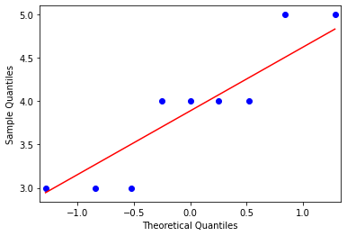

```python
data = DF_dic_goals["Goals: 1930 - 1970"].sort_values()
fig = sm.qqplot(data, stats.norm, line='s')
teststatistik, pwert = stats.shapiro(DF_dic_goals["Goals: 1930 - 1970"])
print(teststatistik)
print(pwert)
```

```
0.6172778010368347
0.0001525924599263817
```

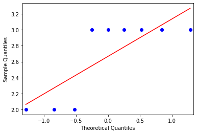

```python
data = DF_dic_goals["Goals: 1982 - 2014"].sort_values()
fig = sm.qqplot(data, stats.norm, line='s')
teststatistik, pwert = stats.shapiro(DF_dic_goals["Goals: 1982 - 2014"])
print(teststatistik)
print(pwert)
```

### 3.4 Mann-Witney Test:

```python
stats.mannwhitneyu(DF_dic_goals["Goals: 1930 - 1970"], DF_dic_goals["Goals: 1982 - 2014"],
                   use_continuity=True, alternative="greater")
```

```
MannwhitneyuResult(statistic=72.0, pvalue=0.0015857333582732299)
```

## 4.0 Fazit

Die Fussballgeschichte zeigt immer wieder spannende Daten welche veröffentlicht werden, für mich war die Analyse der Fussballweltmeisterschaft ein genuss.

## 5.0 Quellenverzeichnis

**Kapitel 1.0 Einleitung**

- https://de.wikipedia.org/wiki/Fu%C3%9Fball-Weltmeisterschaft

**Kapitel 2.0 Beschreibende Statistik**

- https://moodle.bfh.ch/mod/folder/view.php?id=993565 (data_visualisation_gapminder.ipynb)

**Kapitel 3.0 Schliessende Statistik**

- https://moodle.bfh.ch/mod/resource/view.php?id=1048774 (t-Test two independent samples)